# R Notebook

# Hypothesis testing!

## Team members:

# Matvii Prytula, Anastasiia Senyk, Yaroslav Korch

```r
require(BSDA)
library(BSDA)
require(EnvStats)
library(EnvStats)
```

```r
id <- 21
k <- c(1:100)
l <- c(1:50)

# func to generate a_k for x_k
gen <- function(k) {
  return((k * log(k^2 * id + pi)) %% 1)
}
```

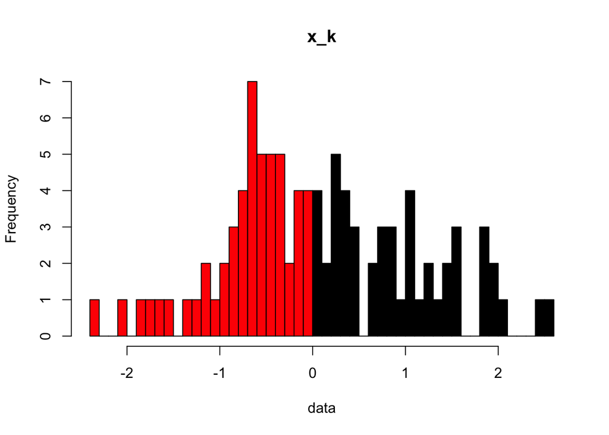

```r
#generating data
a_k <- sapply(k, gen)
a_l <- sapply(l + 100, gen)
x_k <- qnorm(a_k)
y_l <- qnorm(a_l)

x <- x_k
y <- y_l

#plotting data
my_plot <- function(data, title, breaks_num) {
  h <- hist(data, breaks = breaks_num, plot = FALSE)
  cuts <- cut(h$breaks, c(-Inf, -.005, Inf))
  plot(h, col = c("red", "black")[cuts], main = title)
}

my_plot(x_k, "x_k", 50)
```

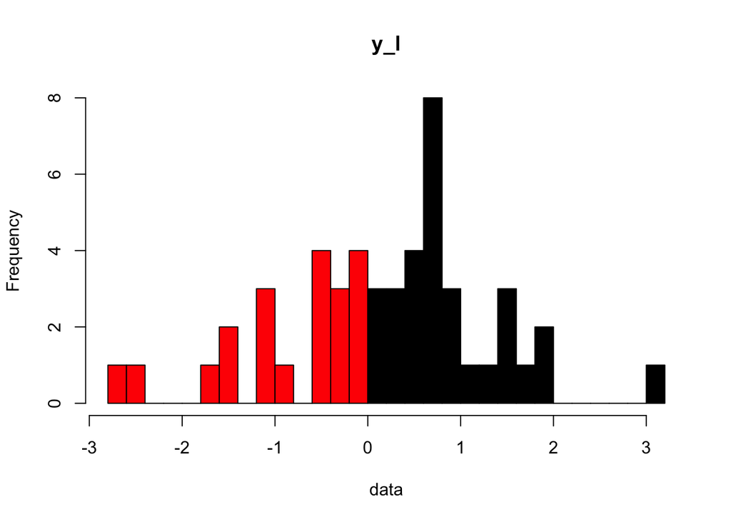

```r
my_plot(y_l, "y_l", 25)
```

# Problem 1. $H_0 : μ_1 =μ_2 \ vs. \ H_1 :μ_1 \ne μ_2; \ σ_1 = σ_2 =1$

```r
z.test(x = x, y = y, alternative = "t", sigma.x = 1, sigma.y = 1)
```

```
##
##  Two-sample z-Test
##
## data:  x and y
## z = -0.67681, p-value = 0.4985
## alternative hypothesis: true difference in means is not equal to 0
## 95 percent confidence interval:
##  -0.4567031  0.2222484
## sample estimates:
## mean of x mean of y
## 0.0744956 0.1917230
```

### We test whether **x_k** and **y_l** means are equal – $H_0$, or not – $H_1$. We can apply a z-test, since we are given the variance.

The **alternative = “t”** means two-sided check. The p-value turns out to be $\approx$ 0.49: $p_{val} > \alpha$ which tells that we should not reject the null hypothesis. The difference of means lies in the $95%$ confidence interval, as expected.

# Problem 2. $H_0:σ_1=σ_2 vs. H_1:σ1_>σ_2; μ_1 \ and \ μ_2 \ are \ unknown$

```r
var.test(x, y, alternative = "g")
```

```
##
##  F test to compare two variances
##
## data:  x and y
## F = 0.85565, num df = 99, denom df = 49, p-value = 0.746
## alternative hypothesis: true ratio of variances is greater than 1
## 95 percent confidence interval:
##  0.5588843       Inf
## sample estimates:
## ratio of variances
##          0.8556511
```

We do not reject the null hypothesis as we can see that the ratio of variances is $\approx 0.85$, which is close to $1$, and $p_{val} > \alpha$. Also one can see that the ratio of variances lies in the confidence interval.

# 3. Using Kolmogorov–Smirnov test in R

### a) $\{x_k\}_{k=1}^{100}$ are normally distributed (with parameters calculated from the sample);

```r
ks.test(x, "pnorm")
```

```
##
##  Asymptotic one-sample Kolmogorov-Smirnov test
##
## data:  x
## D = 0.072837, p-value = 0.6636
## alternative hypothesis: two-sided
```

$H_0$ – data is drawn from a normal distribution. $H_1$ – not from a normal one. The $p-value$ is large, so we can’t reject the null hypothesis.

### b) $\{|x_k|\}_{k=1}^{100}$ k=1 are exponentially distributed with λ = 1

```r
ks.test(abs(x), "exp")
```

```
##
##  Asymptotic one-sample Kolmogorov-Smirnov test
##
## data:  abs(x)
## D = 12.326, p-value < 2.2e-16
## alternative hypothesis: two-sided
```

### c) $\{x_k\}_{k=1}^{100}$ and $\{y_l\}_{l=1}^{50}$ have the same distributions.

```r
ks.test(x, y)
```

```
##
##  Exact two-sample Kolmogorov-Smirnov test
##
## data:  x and y
## D = 0.17, p-value = 0.2811
## alternative hypothesis: two-sided
```

$H_0$ – x and y are drawn from the same distribution. $H_1$ – from different distributions. We do not have enough evidence to reject the null hypothesis, since $p-value$ is relatively big.

### Results: you never know :=)